# Visualizations in R

### Layering Graphs

Most things that get layered already have functions (abline, points, etc), but if you want to layer another graph on top of an existing graph, you can use the `new` option in the `par` command.

**Note**: It’ll stack the graphs as they would have been plotted on their own, so you’ll need to make sure that the axes have the same scale and the title and lables don’t interfere with each other.

*Code*: `par(new = TRUE)`

*Example*:

We have a function that plots an item characteristic curve given its item parameter estimates (see the Analysis in R file to get the code for this function). Since it produces a new graph instead of plotting on top of an existing graph like `abline` does, we need to use the `new` option if we want to plot multiple ICCs on the same window.

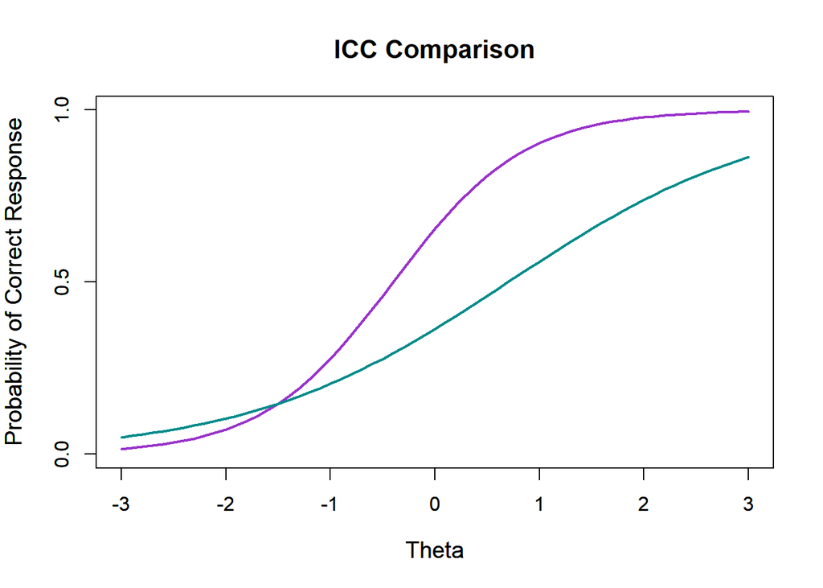

```r
icc(b = -0.4,
    a = 1.6,
    color = "darkorchid",
    title = "ICC Comparison")

par(new = TRUE) # Need this to stack
icc(b = 0.7,
    a = 0.8,
    color = "darkcyan",
    title = "") # Leaving this blank.  Could also just rewrite the same title
```

### Outer text

If you have a split graphing window and want to add an overall title, change the outer top margin and add a main text.

#### Outer top margin

*Code*: `par(oma = c(bottom, left, top, right))`

*Default*: `par(oma = c(0, 0, 0, 0))`

#### Outer main text

*Code*: `mtext("text", outer = TRUE)`

#### Example

Let’s graph the score histograms, but we’ll add a main title.

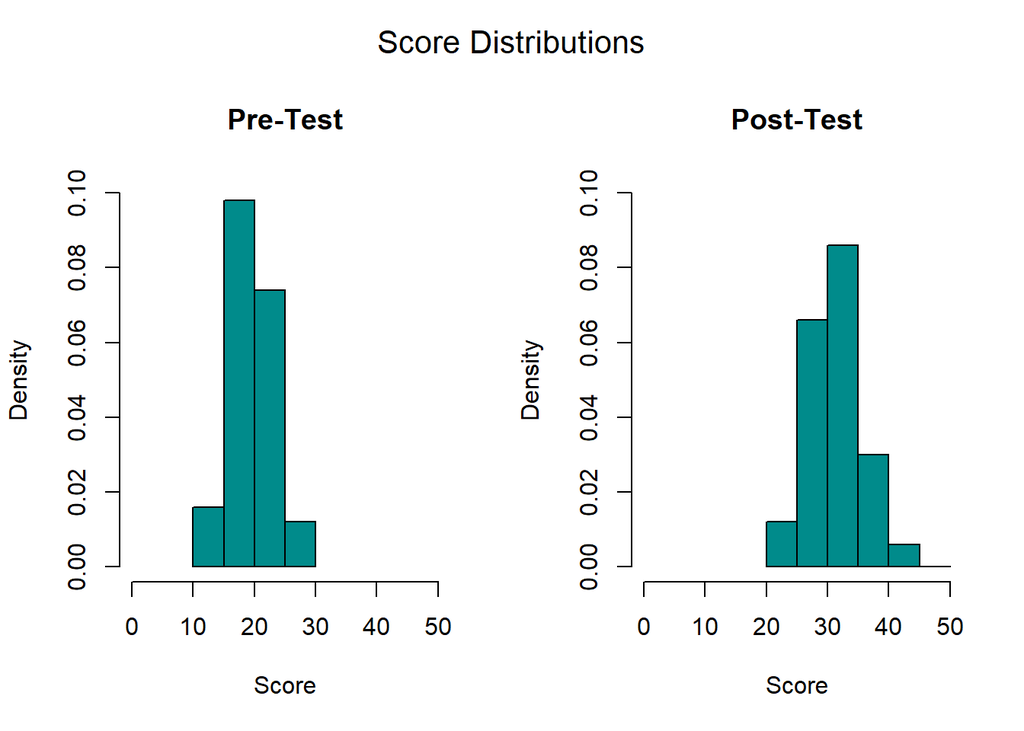

```r
par(mfrow = c(1, 2),
    oma = c(0, 0, 2, 0))

hist(scores$pre,
     freq = FALSE,
     col = "darkcyan",
     xlab = "Score",
     xlim = c(0, 50),
     breaks = seq(min(scores$pre) - (min(scores$pre) %% 5),
                  max(scores$pre) + (5 - (max(scores$pre) %% 5)),
                  5),
     ylim = c(0, 0.1),
     main = "Pre-Test")

hist(scores$post,
     freq = FALSE,
     col = "darkcyan",
     xlab = "Score",
     xlim = c(0, 50),
     breaks = seq(min(scores$post) - (min(scores$post) %% 5),
                  max(scores$post) + (5 - (max(scores$post) %% 5)),
                  5),
     ylim = c(0, 0.1),
     main = "Post-Test")

mtext("Score Distributions",
      outer = TRUE,
      cex = 1.3)
```

### Border Options

You can change the outer border of the main graph by using the `bty` option

The image below illustrates the different types of outlines you can have.

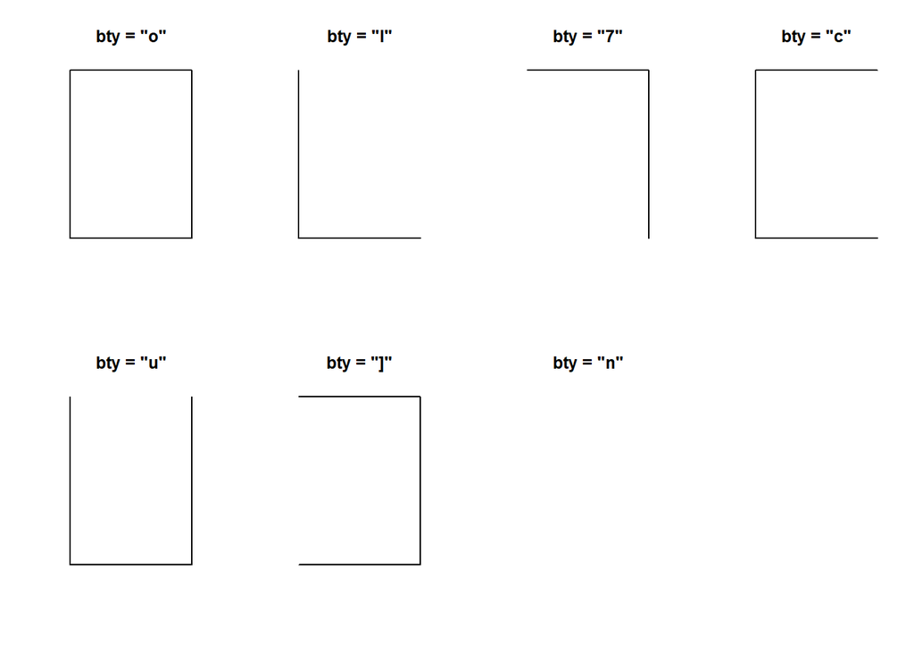

*Code*: `par(bty = "option")`

*Example*:

Let’s plot students’ pre- and post-test scores. We’ll make the plot only have borders on the bottom and left sides.

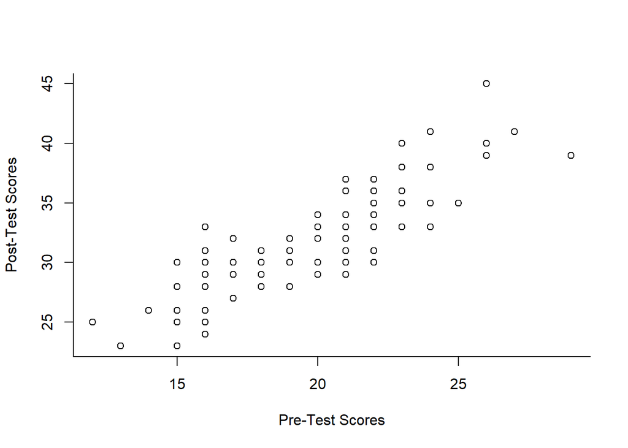

```r
par(bty = "l")
plot(scores$pre,
     scores$post,
     xlab = "Pre-Test Scores",
     ylab = "Post-Test Scores")
```

## Image Sizing

The plot will take the size and shape of the Plots pane in RStudio. If you want to plot multiple graphs in one window, you may want to stretch the Plots pane, so there’s more space in whichevery direction you need it.

You can also make the image a certain number of pixels when you use the Export button. You can click “Update Preview” to see what it will look like with those dimensions before you save.